# R project Final

Ajay

12/8/2019

### Data summary

Is there a significant difference in income between men and women?

To address this problem we will use the NLSY79 (National Longitudinal Survey of Youth, 1979 cohort) data set. The NLSY79 data set contains survey responses on thousands of individuals who have been surveyed every one or two years starting in 1979.

In 2012 survey, there were a total of 5385 people who did not responded to the interview question, as a result we are eliminating them from the dataset as we do not have information on them.

Since income is the depentend variable, we can not have missing income values in the data. Also, we can not impute values in income as it is the variable we are trying to predict. Therefore, we omit missing values from our dataset.

We have defined a function to distriture missing values to other non-missing factor levels because we do not want to get rid of the entire row which might contain other useful information.

We have recorded industry_2012 variable according to the given categories of industies and businesses. We have made the missing values as a separate factor level within the variable.We have distributed the uncodeable values and Not in Labor Force vales(as it was only 1) across the rest of the factor levels.

There were some “Don’t Know” and “Invalid Skip” values in Gender_roles variable that we have distributed across rest of the factor levels randomly.

Similarly, there were 60 valid skips and 150 values for unknown in current_residence variable. We distributed randomly into rural and urban categories.

Variables such as FAMSIZE_2012, Jobsnum_2012, education_level, race and gender were already clean.

Total number of observations and variables in the dataset

```
## [1] 7024   67
```

Income and Gender

Creating a boxplot showing how income varies between gender

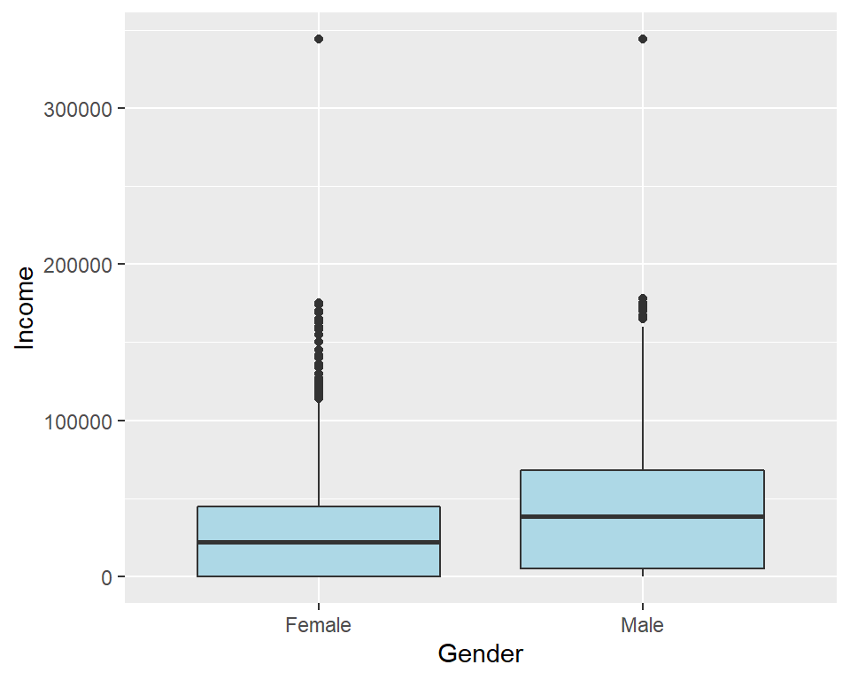

This plot suggests that being female is associated with lower income.

How can we assess whether this difference is statistically significant?

Let’s compute a summary table

| gender | mean.income | sd.income |
| --- | --- | --- |
| Female | 29539 | 35330 |
| Male | 53446 | 69369 |

| gender | num.obs | mean.income | sd.income | se.income |
| --- | --- | --- | --- | --- |
| Female | 3617 | 29539 | 35330 | 587 |
| Male | 3407 | 53446 | 69369 | 1188 |

This table shows that males, on average, earn more than females.

t-test via t.test()

```
##
##  Welch Two Sample t-test
##
## data:  income by gender
## t = -18.034, df = 4993, p-value < 2.2e-16
## alternative hypothesis: true difference in means is not equal to 0
## 95 percent confidence interval:
##  -26506.37 -21308.43
## sample estimates:
## mean in group Female   mean in group Male
##             29538.51             53445.91
```

We see from this output that the difference in income is highly significant for males and females.

Calculate difference in means between males and females

```
## mean in group Female   mean in group Male
##             29538.51             53445.91
```

However, this does not give a wholesome picture of the differences in income between gender.Therefore, we would explore other variables that might explain some of the difference in income.

Difference in average income between men and women for each race category.

| race | mean.income | se.income |
| --- | --- | --- |
| Black | 28325 | 809 |
| Hispanic | 36554 | 1331 |
| Other | 50839 | 1101 |

```
##               Df    Sum Sq      Mean Sq F value Pr(>F)
## race           2 7.131e+11 356570148511   118.1 <2e-16 ***
## Residuals   7021 2.119e+13   3018523856
## ---
## Signif. codes:  0 '***' 0.001 '**' 0.01 '*' 0.05 '.' 0.1 ' ' 1
```

The p-value is significant at the 0.05 level, so the data suggests that there is an association between income and race.

| race | income.gap |
| --- | --- |
| Black | 8683 |
| Hispanic | 18190 |
| Other | 35543 |

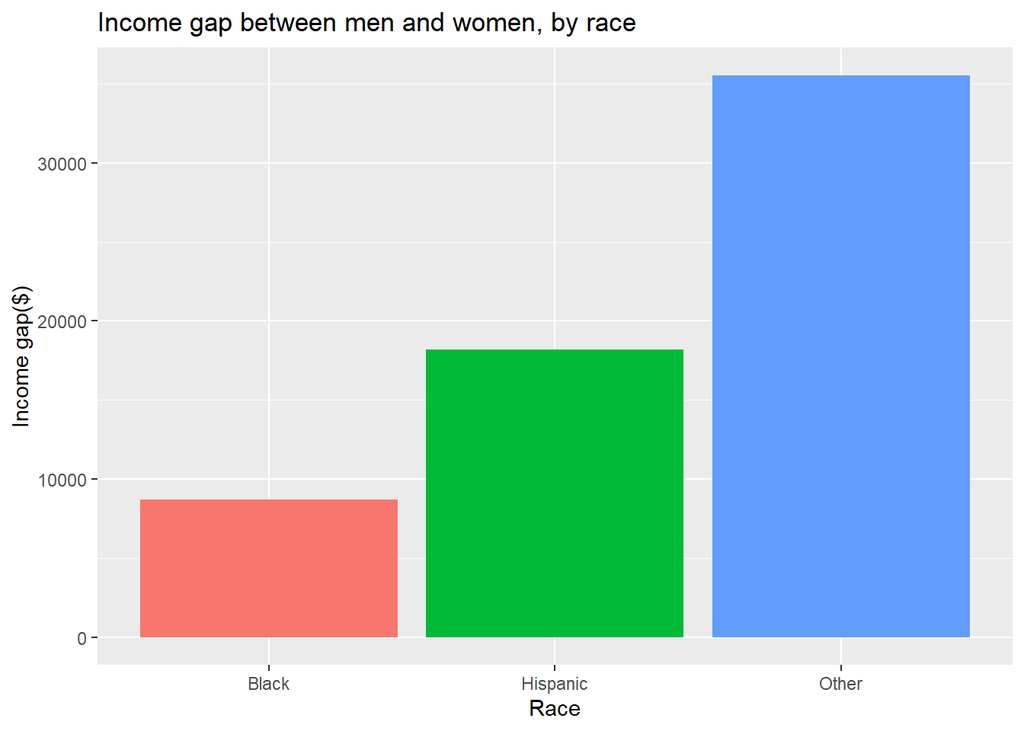

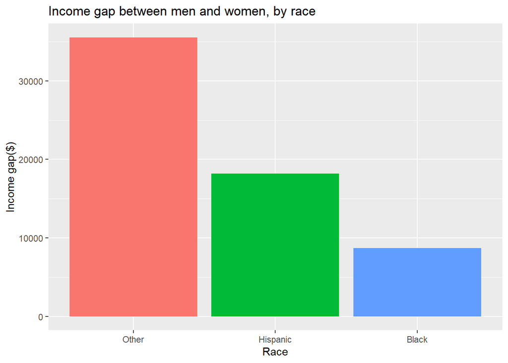

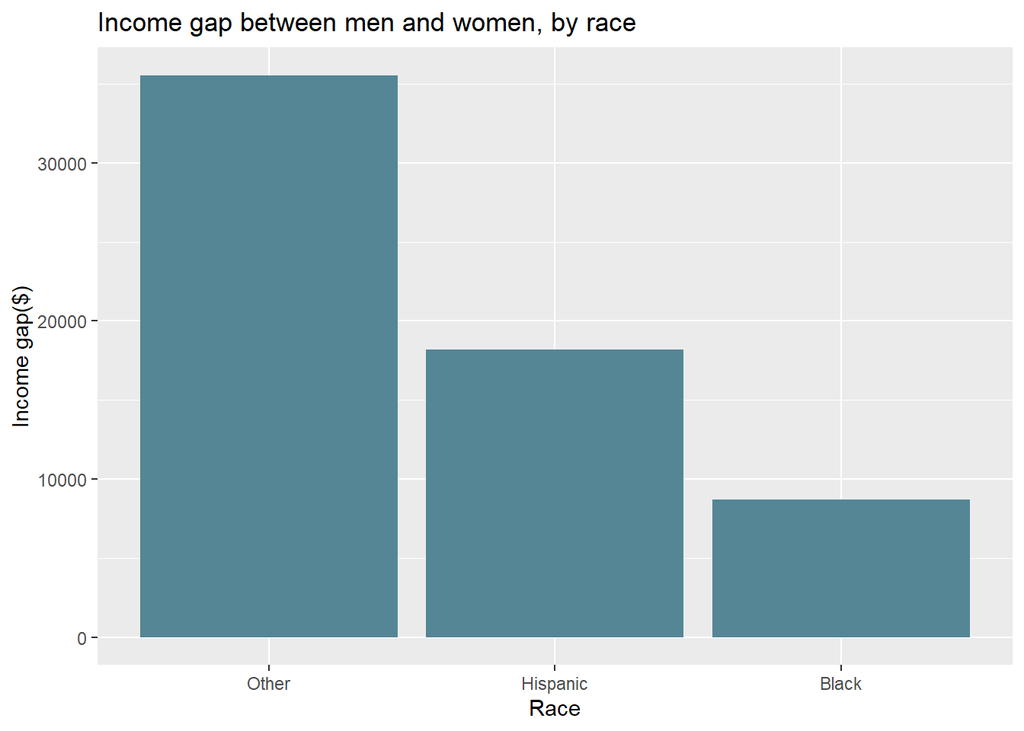

| race | income.gap | upper | lower | is.significant |
| --- | --- | --- | --- | --- |
| Black | 8683.128 | 11877.22 | 5489.032 | 1 |
| Hispanic | 18190.173 | 23441.09 | 12939.252 | 1 |
| Other | 35542.667 | 39772.72 | 31312.609 | 1 |

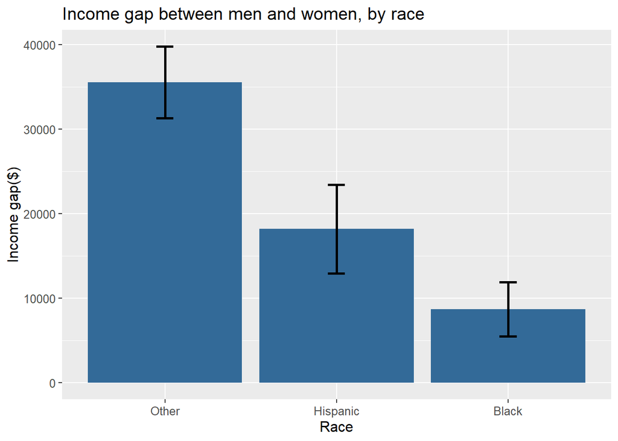

This plot shows that the income difference between males and females in each of the races is statistically significant from zero. Also, the difference in income among gender in different races is statistically significant from each other. For instance, the income gap among gender in Hispanic is higher than in black and this difference is statistically significant.

Check the difference in average income between men and women for rural-urban location.

| current_residence | mean.bwt | se.bwt |
| --- | --- | --- |
| RURAL | 35656 | 1231 |
| URBAN | 42528 | 774 |

```
##                     Df    Sum Sq     Mean Sq F value    Pr(>F)
## current_residence    1 5.361e+10 53612336240   17.23 0.0000336 ***
## Residuals         7022 2.185e+13  3112017083
## ---
## Signif. codes:  0 '***' 0.001 '**' 0.01 '*' 0.05 '.' 0.1 ' ' 1
```

The p-value is significant at the 0.001 level, so the data suggests that there is an association between income and current_residence.

| current_residence | income.gap |
| --- | --- |
| RURAL | 19986 |
| URBAN | 24872 |

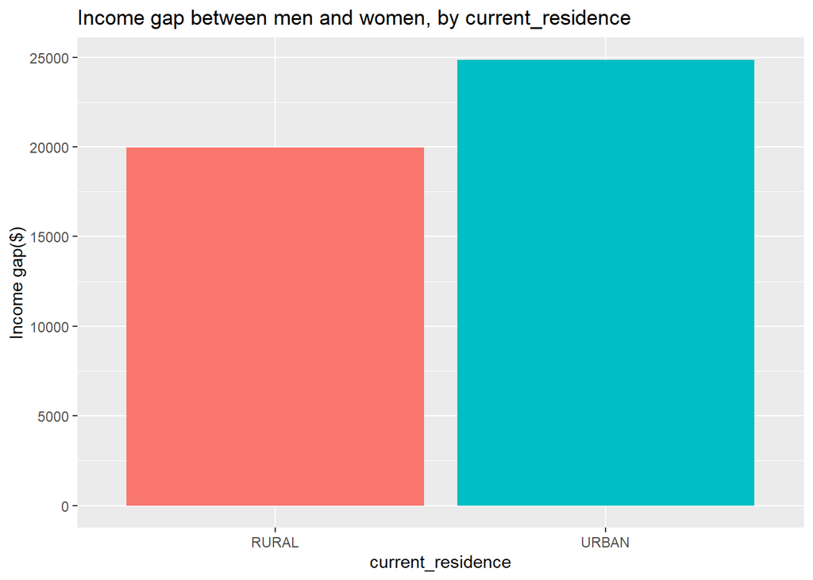

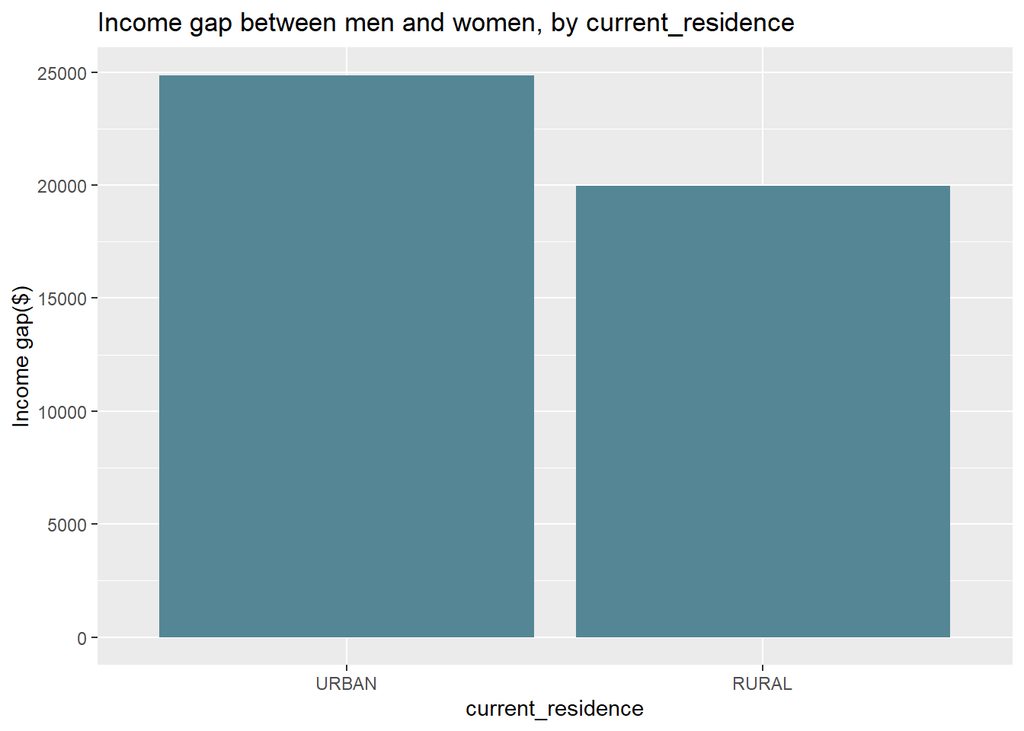

| current_residence | income.gap | upper | lower | is.significant |
| --- | --- | --- | --- | --- |
| RURAL | 19986.61 | 24808.96 | 15164.26 | 1 |
| URBAN | 24871.32 | 27885.97 | 21856.66 | 1 |

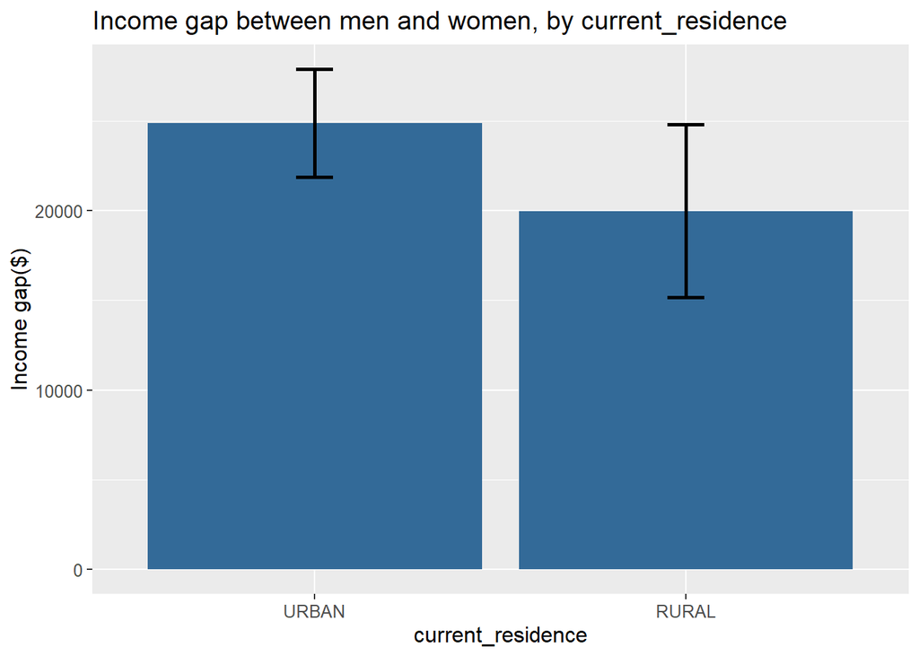

This plot shows that the income difference between males and females in rural and urban is statistically significant from zero. However, the difference in income among gender in urban is not statistically significant than in rural because the error bars overlap with each other.

Relation between years of education and income

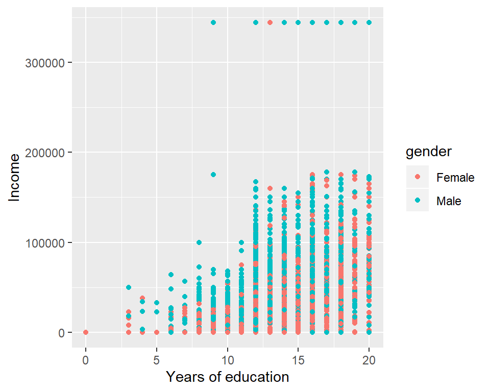

This plot shows that people with higher years of education are more likely to have higher income.

Relation between number of jobs and income

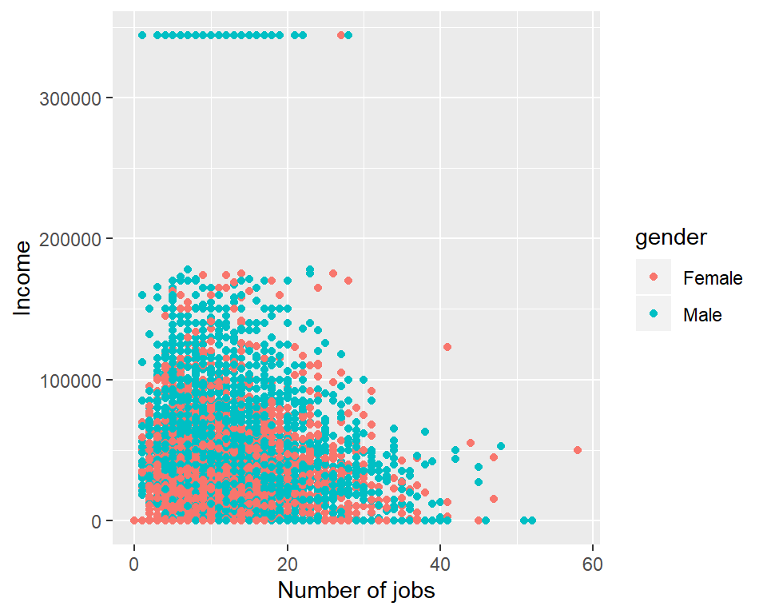

This plot shows that people who have had more number of jobs tend to have lower income.

Current_residence(Rural-Urban)

|  | RURAL | URBAN |
| --- | --- | --- |
| Female | 740 | 2877 |
| Male | 684 | 2723 |

```
##
##  Fisher's Exact Test for Count Data
##
## data:  genderby.location
## p-value = 0.6996
## alternative hypothesis: true odds ratio is not equal to 1
## 95 percent confidence interval:
##  0.9098652 1.1524531
## sample estimates:
## odds ratio
##   1.023963
```

We produced this test to reveal any intereting trends but it din not. An odds ratio of 1 means that being a female or a male does not affect the odds of belonging to rural or urban.

Gender roles and Family attitudes

|  | Female | Male |
| --- | --- | --- |
| STRONGLY DISAGREE | 1420 | 508 |
| DISAGREE | 1623 | 1803 |
| AGREE | 406 | 788 |
| STRONGLY AGREE | 168 | 308 |

Taking extreme attitudes

|  | Female | Male |
| --- | --- | --- |
| STRONGLY DISAGREE | 1420 | 508 |
| STRONGLY AGREE | 168 | 308 |

```
##
##  Fisher's Exact Test for Count Data
##
## data:  genderattitudes
## p-value < 2.2e-16
## alternative hypothesis: true odds ratio is not equal to 1
## 95 percent confidence interval:
##  4.117023 6.384813
## sample estimates:
## odds ratio
##   5.120603
```

This test show that the odds of disagreeing with traditional gender roles are 5.1 times greater when the gender is female than when the gender is male.

[output not shown]

```
##                Df    Sum Sq     Mean Sq F value    Pr(>F)
## gender_roles    3 8.058e+10 26861032495    8.64 0.0000101 ***
## Residuals    7020 2.183e+13  3109061708
## ---
## Signif. codes:  0 '***' 0.001 '**' 0.01 '*' 0.05 '.' 0.1 ' ' 1
```

The p-value is significant at the 0.01 level, so the data suggests that there is an association between income and gender_roles.

[output not shown]

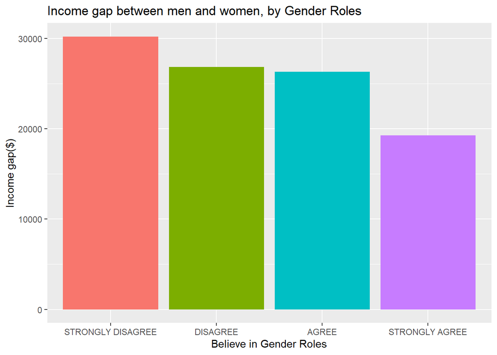

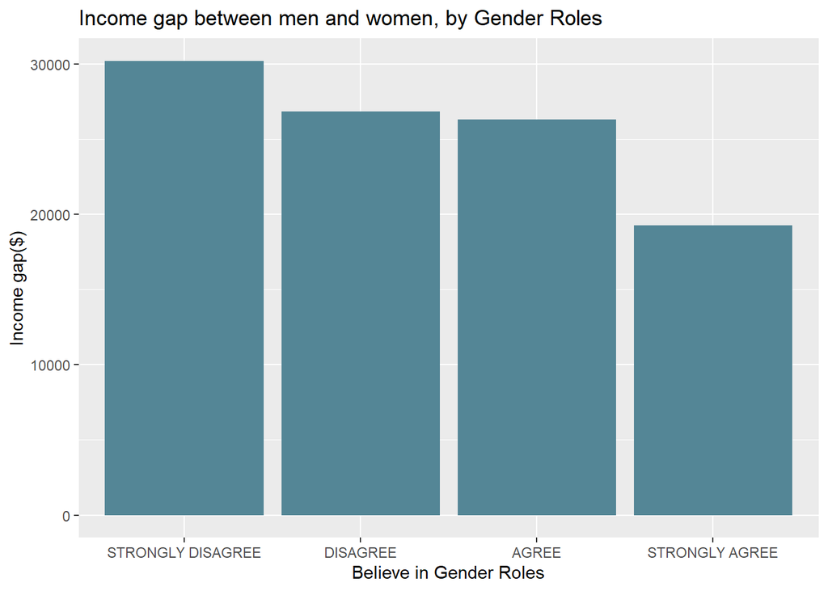

| gender_roles | income.gap | upper | lower | is.significant |
| --- | --- | --- | --- | --- |
| STRONGLY DISAGREE | 30200.38 | 37477.35 | 22923.41 | 1 |
| DISAGREE | 26845.53 | 30405.96 | 23285.09 | 1 |
| AGREE | 26310.10 | 32249.21 | 20370.98 | 1 |
| STRONGLY AGREE | 19241.26 | 26296.58 | 12185.95 | 1 |

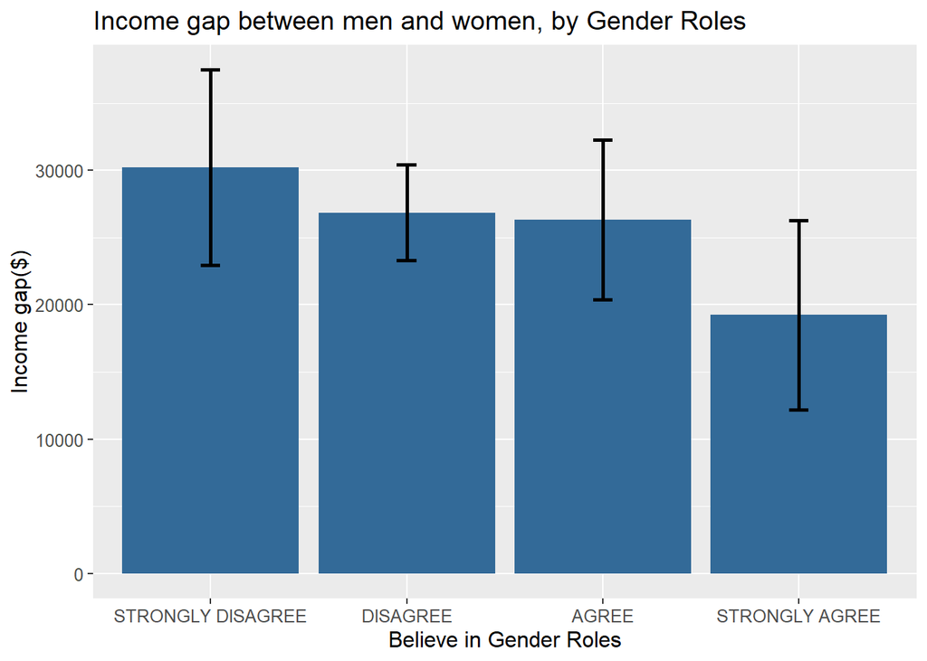

Check the difference in average income between men and women for different industries.

| industry_2012 | income.gap |
| --- | --- |
| Agricultural and Forestry | 22755.783 |
| Mining | 11720.490 |
| Utilities | 25670.197 |
| Construction | 2879.714 |
| Manufacturing | 28218.899 |
| Wholesale Trade | 27321.823 |
| Retail Trade | 28073.407 |
| Transportation | 12122.458 |
| Information | 47801.609 |
| Finance & Insurance | 89551.634 |
| Real Estate | -1976.552 |
| Technical Services | 65747.375 |
| Management Services | 8393.444 |
| Educational Services | 18493.961 |
| Health Care | 41311.132 |
| Arts & Entertainment | 9884.088 |
| Accomodations & Food | 21192.887 |
| Other Services | 22956.102 |
| Public Administration | 20428.533 |
| Armed Forces | -5833.333 |
| Missing | 9901.877 |

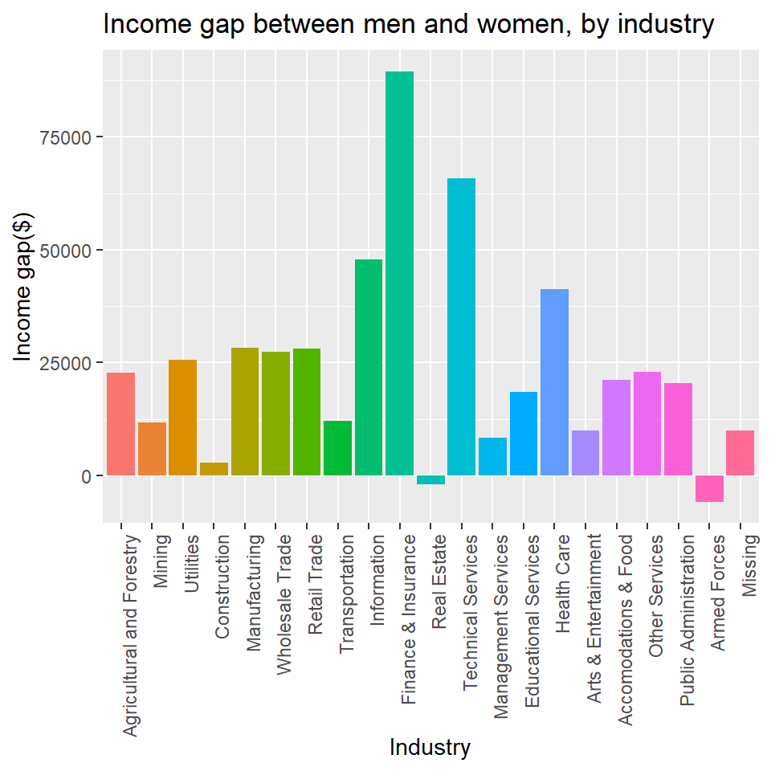

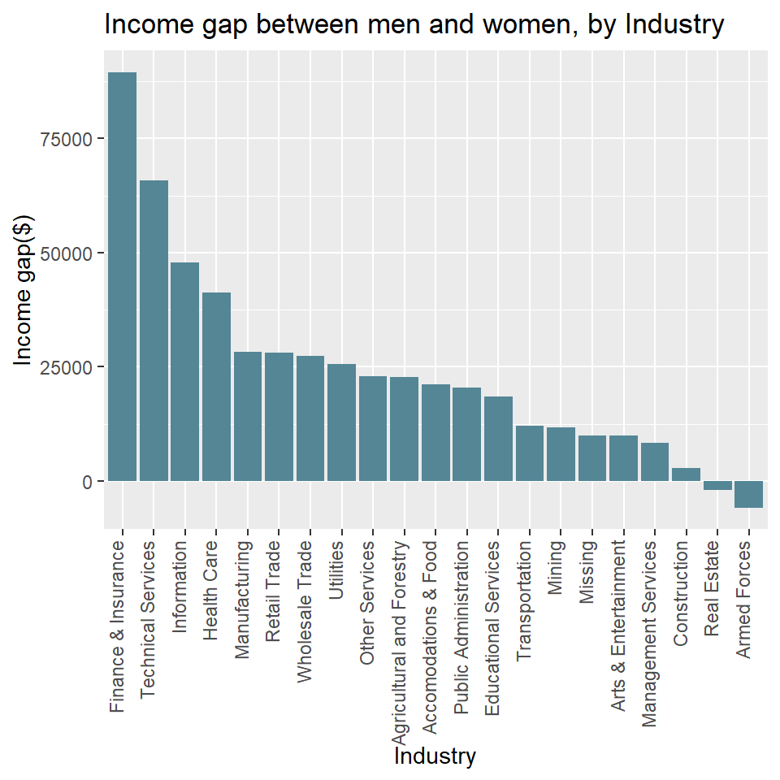

| industry_2012 | income.gap | lower | upper | is.significant |
| --- | --- | --- | --- | --- |
| Agricultural and Forestry | 22755.783 | 7274.9050 | 38236.66 | 1 |
| Mining | 11720.490 | -55172.6185 | 78613.60 | 0 |
| Utilities | 25670.197 | -2814.2760 | 54154.67 | 0 |
| Construction | 2879.714 | -7346.1000 | 13105.53 | 0 |
| Manufacturing | 28218.899 | 20667.5715 | 35770.23 | 1 |
| Wholesale Trade | 27321.823 | 8285.5992 | 46358.05 | 1 |
| Retail Trade | 28073.407 | 19433.6021 | 36713.21 | 1 |
| Transportation | 12122.458 | 2068.9115 | 22176.00 | 1 |
| Information | 47801.609 | 27753.4456 | 67849.77 | 1 |
| Finance & Insurance | 89551.634 | 63590.9154 | 115512.35 | 1 |
| Real Estate | -1976.552 | -24054.4266 | 20101.32 | 0 |
| Technical Services | 65747.375 | 45267.4813 | 86227.27 | 1 |
| Management Services | 8393.444 | -529.0409 | 17315.93 | 0 |
| Educational Services | 18493.961 | 9490.8796 | 27497.04 | 1 |
| Health Care | 41311.132 | 27048.1528 | 55574.11 | 1 |
| Arts & Entertainment | 9884.088 | -3689.5006 | 23457.68 | 0 |
| Accomodations & Food | 21192.887 | 8767.4248 | 33618.35 | 1 |
| Other Services | 22956.102 | 12844.1366 | 33068.07 | 1 |
| Public Administration | 20428.533 | 12735.3873 | 28121.68 | 1 |
| Armed Forces | -5833.333 | -86178.7643 | 74512.10 | 0 |
| Missing | 9901.877 | 4234.1471 | 15569.61 | 1 |

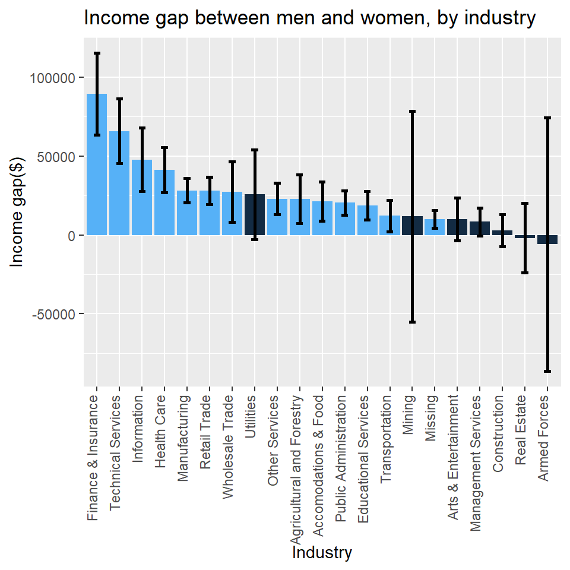

As a result of our analysis, we have decided to include race, current_residence, FAMSIZE_2012, Jobsnum_2012, education_levels, industry_2012 and gender_roles into our final model.

Regression

Checking each individual variable one by one for our regression model

```
##
## Call:
## lm(formula = income ~ gender + education_level, data = nlsy)
##
## Residuals:
##     Min      1Q  Median      3Q     Max
## -113585  -25375   -7085   15625  327072
##
## Coefficients:
##                 Estimate Std. Error t value Pr(>|t|)
## (Intercept)     -89132.8     3243.6  -27.48   <2e-16 ***
## genderMale       26669.0     1189.5   22.42   <2e-16 ***
## education_level   8802.5      232.6   37.84   <2e-16 ***
## ---
## Signif. codes:  0 '***' 0.001 '**' 0.01 '*' 0.05 '.' 0.1 ' ' 1
##
## Residual standard error: 49730 on 7021 degrees of freedom
## Multiple R-squared:  0.2074, Adjusted R-squared:  0.2072
## F-statistic: 918.5 on 2 and 7021 DF,  p-value: < 2.2e-16
```

```
## Analysis of Variance Table
##
## Model 1: income ~ gender
## Model 2: income ~ gender + education_level
##   Res.Df            RSS Df     Sum of Sq      F    Pr(>F)
## 1   7022 20903427347447
## 2   7021 17363143216115  1 3540284131332 1431.6 < 2.2e-16 ***
## ---
## Signif. codes:  0 '***' 0.001 '**' 0.01 '*' 0.05 '.' 0.1 ' ' 1
```

Education_level turns out to be a highly statistically signficant predictor of income in the model.

```
##
## Call:
## lm(formula = income ~ gender + education_level + industry_2012,
##     data = nlsy)
##
## Residuals:
##     Min      1Q  Median      3Q     Max
## -134411  -24735   -5271   13939  319315
##
## Coefficients:
##                                    Estimate Std. Error t value
## (Intercept)                        -86847.2     6369.5 -13.635
## genderMale                          25726.8     1262.2  20.383
## education_level                      8046.2      242.2  33.225
## industry_2012Mining                 31610.9     9764.1   3.237
## industry_2012Utilities              32858.4     7924.9   4.146
## industry_2012Construction           -1337.0     5978.9  -0.224
## industry_2012Manufacturing          17599.2     5837.7   3.015
## industry_2012Wholesale Trade        24003.9     6662.2   3.603
## industry_2012Retail Trade            4239.2     5946.3   0.713
## industry_2012Transportation         15626.9     6089.2   2.566
## industry_2012Information            18598.9     6947.9   2.677
## industry_2012Finance & Insurance    38082.4     6341.2   6.006
## industry_2012Real Estate             5487.5     7183.8   0.764
## industry_2012Technical Services     34706.4     6275.4   5.531
## industry_2012Management Services    -3600.4     6083.2  -0.592
## industry_2012Educational Services   -1284.7     5983.7  -0.215
## industry_2012Health Care            10607.6     5838.3   1.817
## industry_2012Arts & Entertainment   -7460.3     7383.7  -1.010
## industry_2012Accomodations & Food    -482.0     6248.2  -0.077
## industry_2012Other Services         -1059.6     6191.2  -0.171
## industry_2012Public Administration  15199.3     6064.9   2.506
## industry_2012Armed Forces           -6540.0    15556.7  -0.420
## industry_2012Missing               -11509.6     5912.8  -1.947
##                                        Pr(>|t|)
## (Intercept)                             < 2e-16 ***
## genderMale                              < 2e-16 ***
## education_level                         < 2e-16 ***
## industry_2012Mining                    0.001212 **
## industry_2012Utilities             0.0000342023 ***
```

[output cut: 9 more lines]

```
## industry_2012Management Services       0.553965
## industry_2012Educational Services      0.830014
## industry_2012Health Care               0.069274 .
## industry_2012Arts & Entertainment      0.312354
## industry_2012Accomodations & Food      0.938507
## industry_2012Other Services            0.864116
## industry_2012Public Administration     0.012230 *
## industry_2012Armed Forces              0.674208
## industry_2012Missing                   0.051627 .
## ---
## Signif. codes:  0 '***' 0.001 '**' 0.01 '*' 0.05 '.' 0.1 ' ' 1
##
## Residual standard error: 48150 on 7001 degrees of freedom
## Multiple R-squared:  0.2591, Adjusted R-squared:  0.2568
## F-statistic: 111.3 on 22 and 7001 DF,  p-value: < 2.2e-16
```

```
## Analysis of Variance Table
##
## Model 1: income ~ gender + education_level
## Model 2: income ~ gender + education_level + industry_2012
##   Res.Df            RSS Df     Sum of Sq      F    Pr(>F)
## 1   7021 17363143216115
## 2   7001 16230061772252 20 1133081443863 24.438 < 2.2e-16 ***
## ---
## Signif. codes:  0 '***' 0.001 '**' 0.01 '*' 0.05 '.' 0.1 ' ' 1
```

Industry_2012 turns out to be a highly statistically signficant predictor of income in the model

```
##
## Call:
## lm(formula = income ~ gender + education_level + industry_2012 +
##     race, data = nlsy)
##
## Residuals:
##     Min      1Q  Median      3Q     Max
## -136947  -24183   -4557   14126  319774
##
## Coefficients:
##                                    Estimate Std. Error t value Pr(>|t|)
## (Intercept)                        -95166.1     6388.7 -14.896  < 2e-16
## genderMale                          26057.3     1251.1  20.828  < 2e-16
## education_level                      7797.3      244.6  31.881  < 2e-16
## industry_2012Mining                 29820.4     9677.7   3.081 0.002069
## industry_2012Utilities              34081.1     7853.3   4.340 1.45e-05
## industry_2012Construction            -776.1     5924.5  -0.131 0.895785
## industry_2012Manufacturing          18402.9     5785.0   3.181 0.001473
## industry_2012Wholesale Trade        24172.8     6601.3   3.662 0.000252
## industry_2012Retail Trade            5298.6     5892.7   0.899 0.368589
## industry_2012Transportation         18515.3     6038.8   3.066 0.002177
## industry_2012Information            19581.3     6885.2   2.844 0.004468
## industry_2012Finance & Insurance    38784.1     6283.6   6.172 7.11e-10
## industry_2012Real Estate             6425.1     7118.9   0.903 0.366801
## industry_2012Technical Services     35081.1     6218.5   5.641 1.75e-08
## industry_2012Management Services     -402.9     6034.1  -0.067 0.946761
## industry_2012Educational Services     420.9     5931.9   0.071 0.943437
## industry_2012Health Care            13287.6     5790.5   2.295 0.021778
## industry_2012Arts & Entertainment   -6542.4     7316.7  -0.894 0.371256
## industry_2012Accomodations & Food    2725.2     6197.5   0.440 0.660146
## industry_2012Other Services           532.4     6136.2   0.087 0.930857
## industry_2012Public Administration  17855.8     6015.4   2.968 0.003004
## industry_2012Armed Forces           -3075.9    15421.5  -0.199 0.841912
## industry_2012Missing                -8973.5     5863.0  -1.531 0.125932
## raceHispanic                        11363.4     1662.6   6.835 8.90e-12
## raceOther                           15129.7     1330.7  11.370  < 2e-16
##
## (Intercept)                        ***
## genderMale                         ***
## education_level                    ***
```

[output cut: 13 more lines]

```
## industry_2012Health Care           *
## industry_2012Arts & Entertainment
## industry_2012Accomodations & Food
## industry_2012Other Services
## industry_2012Public Administration **
## industry_2012Armed Forces
## industry_2012Missing
## raceHispanic                       ***
## raceOther                          ***
## ---
## Signif. codes:  0 '***' 0.001 '**' 0.01 '*' 0.05 '.' 0.1 ' ' 1
##
## Residual standard error: 47710 on 6999 degrees of freedom
## Multiple R-squared:  0.2728, Adjusted R-squared:  0.2703
## F-statistic: 109.4 on 24 and 6999 DF,  p-value: < 2.2e-16
```

```
## Analysis of Variance Table
##
## Model 1: income ~ gender + education_level + industry_2012
## Model 2: income ~ gender + education_level + industry_2012 + race
##   Res.Df       RSS Df    Sum of Sq      F    Pr(>F)
## 1   7001 1.623e+13
## 2   6999 1.593e+13  2 300178524301 65.944 < 2.2e-16 ***
## ---
## Signif. codes:  0 '***' 0.001 '**' 0.01 '*' 0.05 '.' 0.1 ' ' 1
```

Race turns out to be a highly statistically signficant predictor of income in the model

```
##
## Call:
## lm(formula = income ~ gender + race + education_level + industry_2012 +
##     current_residence, data = nlsy)
##
## Residuals:
##     Min      1Q  Median      3Q     Max
## -132077  -24394   -4834   14490  319055
##
## Coefficients:
##                                    Estimate Std. Error t value Pr(>|t|)
## (Intercept)                        -96708.8     6398.2 -15.115  < 2e-16
## genderMale                          25967.6     1250.3  20.770  < 2e-16
## raceHispanic                        11173.9     1662.1   6.723 1.92e-11
## raceOther                           16064.4     1355.5  11.851  < 2e-16
## education_level                      7712.0      245.5  31.407  < 2e-16
## industry_2012Mining                 28835.5     9673.7   2.981 0.002885
## industry_2012Utilities              32463.6     7860.0   4.130 3.67e-05
## industry_2012Construction           -2638.2     5942.8  -0.444 0.657106
## industry_2012Manufacturing          16745.5     5799.1   2.888 0.003894
## industry_2012Wholesale Trade        21979.7     6624.7   3.318 0.000912
## industry_2012Retail Trade            3421.1     5911.5   0.579 0.562802
## industry_2012Transportation         16607.1     6057.8   2.741 0.006132
## industry_2012Information            17300.5     6909.5   2.504 0.012307
## industry_2012Finance & Insurance    36660.3     6306.9   5.813 6.42e-09
## industry_2012Real Estate             4177.5     7141.2   0.585 0.558577
## industry_2012Technical Services     32613.2     6252.2   5.216 1.88e-07
## industry_2012Management Services    -2257.7     6051.8  -0.373 0.709117
## industry_2012Educational Services   -1277.9     5946.4  -0.215 0.829845
## industry_2012Health Care            11370.4     5810.9   1.957 0.050418
## industry_2012Arts & Entertainment   -8541.6     7332.3  -1.165 0.244089
## industry_2012Accomodations & Food     695.6     6218.7   0.112 0.910937
## industry_2012Other Services         -1324.5     6153.5  -0.215 0.829577
## industry_2012Public Administration  16055.0     6031.8   2.662 0.007792
## industry_2012Armed Forces           -5159.9    15420.0  -0.335 0.737917
## industry_2012Missing               -10857.5     5882.2  -1.846 0.064960
## current_residenceURBAN               5229.2     1474.4   3.547 0.000393
##
## (Intercept)                        ***
## genderMale                         ***
```

[output cut: 15 more lines]

```
## industry_2012Educational Services
## industry_2012Health Care           .
## industry_2012Arts & Entertainment
## industry_2012Accomodations & Food
## industry_2012Other Services
## industry_2012Public Administration **
## industry_2012Armed Forces
## industry_2012Missing               .
## current_residenceURBAN             ***
## ---
## Signif. codes:  0 '***' 0.001 '**' 0.01 '*' 0.05 '.' 0.1 ' ' 1
##
## Residual standard error: 47670 on 6998 degrees of freedom
## Multiple R-squared:  0.2741, Adjusted R-squared:  0.2715
## F-statistic: 105.7 on 25 and 6998 DF,  p-value: < 2.2e-16
```

```
## Analysis of Variance Table
##
## Model 1: income ~ gender + race + education_level + industry_2012
## Model 2: income ~ gender + race + education_level + industry_2012 + current_residence
##   Res.Df            RSS Df   Sum of Sq      F    Pr(>F)
## 1   6999 15929883247951
## 2   6998 15901301710502  1 28581537449 12.578 0.0003928 ***
## ---
## Signif. codes:  0 '***' 0.001 '**' 0.01 '*' 0.05 '.' 0.1 ' ' 1
```

Current_residence turns out to be a highly statistically signficant predictor of income in the model

```
##
## Call:
## lm(formula = income ~ gender + race + education_level + industry_2012 +
##     current_residence + FAMSIZE_2012, data = nlsy)
##
## Residuals:
##     Min      1Q  Median      3Q     Max
## -134811  -24206   -4617   14158  320023
##
## Coefficients:
##                                     Estimate Std. Error t value Pr(>|t|)
## (Intercept)                        -102380.3     6449.7 -15.874  < 2e-16
## genderMale                           26198.7     1247.7  20.998  < 2e-16
## raceHispanic                         10134.2     1666.6   6.081 1.26e-09
## raceOther                            15717.4     1353.2  11.615  < 2e-16
## education_level                       7616.9      245.4  31.036  < 2e-16
## industry_2012Mining                  29905.8     9650.5   3.099 0.001950
## industry_2012Utilities               33563.4     7842.0   4.280 1.89e-05
## industry_2012Construction            -1319.8     5931.6  -0.223 0.823926
## industry_2012Manufacturing           17546.4     5785.7   3.033 0.002433
## industry_2012Wholesale Trade         23056.7     6610.2   3.488 0.000490
## industry_2012Retail Trade             4169.0     5897.7   0.707 0.479667
## industry_2012Transportation          17425.4     6043.8   2.883 0.003949
## industry_2012Information             18204.7     6893.4   2.641 0.008287
## industry_2012Finance & Insurance     37835.6     6293.8   6.012 1.93e-09
## industry_2012Real Estate              5490.7     7126.2   0.770 0.441030
## industry_2012Technical Services      33197.0     6237.0   5.323 1.05e-07
## industry_2012Management Services      -993.5     6039.9  -0.164 0.869352
## industry_2012Educational Services     -593.1     5932.2  -0.100 0.920361
## industry_2012Health Care             12219.1     5797.7   2.108 0.035103
## industry_2012Arts & Entertainment    -6912.2     7318.5  -0.944 0.344951
## industry_2012Accomodations & Food     1749.2     6205.3   0.282 0.778031
## industry_2012Other Services           -358.5     6139.8  -0.058 0.953439
## industry_2012Public Administration   16886.7     6018.0   2.806 0.005029
## industry_2012Armed Forces            -5031.6    15380.6  -0.327 0.743570
## industry_2012Missing                -10203.6     5868.1  -1.739 0.082111
## current_residenceURBAN                5110.0     1470.8   3.474 0.000515
## FAMSIZE_2012                          2449.2      403.0   6.078 1.28e-09
##
## (Intercept)                        ***
```

[output cut: 17 more lines]

```
## industry_2012Health Care           *
## industry_2012Arts & Entertainment
## industry_2012Accomodations & Food
## industry_2012Other Services
## industry_2012Public Administration **
## industry_2012Armed Forces
## industry_2012Missing               .
## current_residenceURBAN             ***
## FAMSIZE_2012                       ***
## ---
## Signif. codes:  0 '***' 0.001 '**' 0.01 '*' 0.05 '.' 0.1 ' ' 1
##
## Residual standard error: 47550 on 6997 degrees of freedom
## Multiple R-squared:  0.2779, Adjusted R-squared:  0.2752
## F-statistic: 103.6 on 26 and 6997 DF,  p-value: < 2.2e-16
```

```
## Analysis of Variance Table
##
## Model 1: income ~ gender + race + education_level + industry_2012 + current_residence
## Model 2: income ~ gender + race + education_level + industry_2012 + current_residence +
##     FAMSIZE_2012
##   Res.Df            RSS Df   Sum of Sq      F    Pr(>F)
## 1   6998 15901301710502
## 2   6997 15817795722731  1 83505987770 36.939 1.283e-09 ***
## ---
## Signif. codes:  0 '***' 0.001 '**' 0.01 '*' 0.05 '.' 0.1 ' ' 1
```

Family size turns out to be a highly statistically signficant predictor of income in the model

```
##
## Call:
## lm(formula = income ~ gender + race + education_level + industry_2012 +
##     current_residence + FAMSIZE_2012 + gender_roles, data = nlsy)
##
## Residuals:
##     Min      1Q  Median      3Q     Max
## -135252  -24150   -4648   14111  319467
##
## Coefficients:
##                                       Estimate  Std. Error t value
## (Intercept)                        -101908.592    6642.559 -15.342
## genderMale                           26230.721    1296.036  20.239
## raceHispanic                         10154.051    1669.256   6.083
## raceOther                            15685.885    1355.010  11.576
## education_level                       7597.858     251.345  30.229
## industry_2012Mining                  29629.300    9663.278   3.066
## industry_2012Utilities               33352.616    7850.597   4.248
## industry_2012Construction            -1505.760    5938.463  -0.254
## industry_2012Manufacturing           17389.196    5793.402   3.002
## industry_2012Wholesale Trade         23040.056    6618.866   3.481
## industry_2012Retail Trade             4010.722    5904.575   0.679
## industry_2012Transportation          17274.512    6052.817   2.854
## industry_2012Information             18055.985    6898.848   2.617
## industry_2012Finance & Insurance     37677.236    6301.963   5.979
## industry_2012Real Estate              5316.995    7131.918   0.746
## industry_2012Technical Services      33051.675    6246.407   5.291
## industry_2012Management Services     -1128.914    6046.772  -0.187
## industry_2012Educational Services     -737.492    5937.679  -0.124
## industry_2012Health Care             12059.371    5804.936   2.077
## industry_2012Arts & Entertainment    -7006.425    7327.953  -0.956
## industry_2012Accomodations & Food     1637.787    6210.637   0.264
## industry_2012Other Services           -476.798    6146.736  -0.078
## industry_2012Public Administration   16732.943    6026.785   2.776
## industry_2012Armed Forces            -5314.910   15388.714  -0.345
## industry_2012Missing                -10291.056    5872.627  -1.752
## current_residenceURBAN                5088.530    1472.635   3.455
## FAMSIZE_2012                          2449.249     403.127   6.076
## gender_rolesDISAGREE                    -3.342    1406.794  -0.002
## gender_rolesAGREE                      498.350    1856.315   0.268
```

[output cut: 23 more lines]

```
## industry_2012Other Services        0.938173
## industry_2012Public Administration 0.005511 **
## industry_2012Armed Forces          0.729821
## industry_2012Missing               0.079753 .
## current_residenceURBAN             0.000553 ***
## FAMSIZE_2012                       1.30e-09 ***
## gender_rolesDISAGREE               0.998105
## gender_rolesAGREE                  0.788352
## gender_rolesSTRONGLY AGREE         0.399167
## ---
## Signif. codes:  0 '***' 0.001 '**' 0.01 '*' 0.05 '.' 0.1 ' ' 1
##
## Residual standard error: 47550 on 6994 degrees of freedom
## Multiple R-squared:  0.278,  Adjusted R-squared:  0.275
## F-statistic: 92.88 on 29 and 6994 DF,  p-value: < 2.2e-16
```

```
## Analysis of Variance Table
##
## Model 1: income ~ gender + race + education_level + industry_2012 + current_residence +
##     FAMSIZE_2012
## Model 2: income ~ gender + race + education_level + industry_2012 + current_residence +
##     FAMSIZE_2012 + gender_roles
##   Res.Df            RSS Df  Sum of Sq      F Pr(>F)
## 1   6997 15817795722731
## 2   6994 15815382620738  3 2413101993 0.3557  0.785
```

Gender_roles is not a statistically signficant predictor of income in the model

```
##
## Call:
## lm(formula = income ~ gender + race + education_level + industry_2012 +
##     current_residence + FAMSIZE_2012 + gender_roles + Jobsnum_2012,
##     data = nlsy)
##
## Residuals:
##     Min      1Q  Median      3Q     Max
## -140977  -23334   -4921   14111  323185
##
## Coefficients:
##                                     Estimate Std. Error t value Pr(>|t|)
## (Intercept)                        -93031.52    6631.34 -14.029  < 2e-16
## genderMale                          27366.70    1288.59  21.238  < 2e-16
## raceHispanic                        10357.68    1654.64   6.260 4.08e-10
## raceOther                           16211.81    1343.88  12.063  < 2e-16
## education_level                      7761.50     249.56  31.101  < 2e-16
## industry_2012Mining                 31422.83    9579.43   3.280 0.001042
## industry_2012Utilities              32705.50    7781.61   4.203 2.67e-05
## industry_2012Construction            1110.83    5890.73   0.189 0.850434
## industry_2012Manufacturing          16835.02    5742.54   2.932 0.003383
## industry_2012Wholesale Trade        23462.32    6560.63   3.576 0.000351
## industry_2012Retail Trade            4527.12    5852.71   0.774 0.439247
## industry_2012Transportation         18758.72    6000.92   3.126 0.001779
## industry_2012Information            18713.27    6838.28   2.737 0.006225
## industry_2012Finance & Insurance    37690.07    6246.41   6.034 1.68e-09
## industry_2012Real Estate             7497.07    7071.72   1.060 0.289113
## industry_2012Technical Services     33838.04    6191.74   5.465 4.79e-08
## industry_2012Management Services     1370.37    5997.60   0.228 0.819275
## industry_2012Educational Services      26.42    5885.73   0.004 0.996419
## industry_2012Health Care            12846.98    5754.19   2.233 0.025605
## industry_2012Arts & Entertainment   -3499.59    7270.07  -0.481 0.630269
## industry_2012Accomodations & Food    3955.03    6159.35   0.642 0.520818
## industry_2012Other Services          1808.15    6095.95   0.297 0.766770
## industry_2012Public Administration  15913.40    5974.10   2.664 0.007746
## industry_2012Armed Forces           -6037.10   15253.20  -0.396 0.692270
## industry_2012Missing               -13165.97    5826.49  -2.260 0.023872
## current_residenceURBAN               5798.86    1461.02   3.969 7.29e-05
## FAMSIZE_2012                         2032.08     401.30   5.064 4.22e-07
## gender_rolesDISAGREE                 -781.41    1396.11  -0.560 0.575700
```

[output cut: 26 more lines]

```
## industry_2012Public Administration **
## industry_2012Armed Forces
## industry_2012Missing               *
## current_residenceURBAN             ***
## FAMSIZE_2012                       ***
## gender_rolesDISAGREE
## gender_rolesAGREE
## gender_rolesSTRONGLY AGREE
## Jobsnum_2012                       ***
## ---
## Signif. codes:  0 '***' 0.001 '**' 0.01 '*' 0.05 '.' 0.1 ' ' 1
##
## Residual standard error: 47130 on 6993 degrees of freedom
## Multiple R-squared:  0.2908, Adjusted R-squared:  0.2878
## F-statistic: 95.59 on 30 and 6993 DF,  p-value: < 2.2e-16
```

```
## Analysis of Variance Table
##
## Model 1: income ~ gender + race + education_level + industry_2012 + current_residence +
##     FAMSIZE_2012 + gender_roles + Jobsnum_2012
## Model 2: income ~ gender + race + education_level + industry_2012 + current_residence +
##     FAMSIZE_2012 + gender_roles + Jobsnum_2012
##   Res.Df            RSS Df Sum of Sq F Pr(>F)
## 1   6993 15535558995044
## 2   6993 15535558995044  0         0
```

JOBSNUM_2012 turns out to be a highly statistically signficant predictor of income in the model

As a result, we are eleminating gender_roles from our model as it does not explain the varibility in income well.

Final regression model

```
##
## Call:
## lm(formula = income ~ gender + race + education_level + industry_2012 +
##     current_residence + FAMSIZE_2012 + Jobsnum_2012, data = nlsy)
##
## Residuals:
##     Min      1Q  Median      3Q     Max
## -140789  -23455   -4894   14037  323390
##
## Coefficients:
##                                    Estimate Std. Error t value Pr(>|t|)
## (Intercept)                        -94401.8     6432.7 -14.675  < 2e-16
## genderMale                          27136.7     1239.5  21.893  < 2e-16
## raceHispanic                        10314.8     1652.1   6.244 4.53e-10
## raceOther                           16212.6     1342.1  12.080  < 2e-16
## education_level                      7805.8      243.8  32.011  < 2e-16
## industry_2012Mining                 31644.3     9567.1   3.308 0.000946
## industry_2012Utilities              32957.5     7773.4   4.240 2.27e-05
## industry_2012Construction            1334.8     5884.3   0.227 0.820561
## industry_2012Manufacturing          17030.3     5735.1   2.969 0.002993
## industry_2012Wholesale Trade        23516.3     6552.3   3.589 0.000334
## industry_2012Retail Trade            4727.2     5846.1   0.809 0.418772
## industry_2012Transportation         18968.3     5992.3   3.165 0.001555
## industry_2012Information            18968.0     6833.2   2.776 0.005521
## industry_2012Finance & Insurance    37904.3     6238.5   6.076 1.30e-09
## industry_2012Real Estate             7748.6     7066.5   1.097 0.272888
## industry_2012Technical Services     34032.9     6182.7   5.505 3.83e-08
## industry_2012Management Services     1543.2     5991.2   0.258 0.796735
## industry_2012Educational Services     204.8     5880.6   0.035 0.972216
## industry_2012Health Care            13028.9     5747.2   2.267 0.023422
## industry_2012Arts & Entertainment   -3360.7     7261.1  -0.463 0.643497
## industry_2012Accomodations & Food    4094.5     6154.4   0.665 0.505883
## industry_2012Other Services          1959.0     6089.4   0.322 0.747686
## industry_2012Public Administration  16127.5     5965.5   2.703 0.006879
## industry_2012Armed Forces           -5766.5    15245.7  -0.378 0.705264
## industry_2012Missing               -13052.7     5822.2  -2.242 0.025000
## current_residenceURBAN               5857.0     1459.4   4.013 6.05e-05
## FAMSIZE_2012                         2029.9      401.2   5.060 4.30e-07
## Jobsnum_2012                         -929.8       83.0 -11.202  < 2e-16
##
```

[output cut: 19 more lines]

```
## industry_2012Arts & Entertainment
## industry_2012Accomodations & Food
## industry_2012Other Services
## industry_2012Public Administration **
## industry_2012Armed Forces
## industry_2012Missing               *
## current_residenceURBAN             ***
## FAMSIZE_2012                       ***
## Jobsnum_2012                       ***
## ---
## Signif. codes:  0 '***' 0.001 '**' 0.01 '*' 0.05 '.' 0.1 ' ' 1
##
## Residual standard error: 47130 on 6996 degrees of freedom
## Multiple R-squared:  0.2907, Adjusted R-squared:  0.2879
## F-statistic: 106.2 on 27 and 6996 DF,  p-value: < 2.2e-16
```

|  | Estimate | Std. Error | t value | Pr(>\|t\|) |
| --- | --- | --- | --- | --- |
| (Intercept) | -94401.805 | 6432.677 | -14.675 | 0.0000 |
| genderMale | 27136.703 | 1239.534 | 21.893 | 0.0000 |
| raceHispanic | 10314.757 | 1652.065 | 6.244 | 0.0000 |
| raceOther | 16212.603 | 1342.066 | 12.080 | 0.0000 |
| education_level | 7805.795 | 243.848 | 32.011 | 0.0000 |
| industry_2012Mining | 31644.256 | 9567.056 | 3.308 | 0.0009 |
| industry_2012Utilities | 32957.469 | 7773.346 | 4.240 | 0.0000 |
| industry_2012Construction | 1334.752 | 5884.316 | 0.227 | 0.8206 |
| industry_2012Manufacturing | 17030.259 | 5735.144 | 2.969 | 0.0030 |
| industry_2012Wholesale Trade | 23516.317 | 6552.273 | 3.589 | 0.0003 |
| industry_2012Retail Trade | 4727.198 | 5846.145 | 0.809 | 0.4188 |
| industry_2012Transportation | 18968.339 | 5992.284 | 3.165 | 0.0016 |
| industry_2012Information | 18967.948 | 6833.234 | 2.776 | 0.0055 |
| industry_2012Finance & Insurance | 37904.270 | 6238.507 | 6.076 | 0.0000 |
| industry_2012Real Estate | 7748.606 | 7066.534 | 1.097 | 0.2729 |
| industry_2012Technical Services | 34032.929 | 6182.664 | 5.505 | 0.0000 |
| industry_2012Management Services | 1543.228 | 5991.158 | 0.258 | 0.7967 |
| industry_2012Educational Services | 204.819 | 5880.566 | 0.035 | 0.9722 |
| industry_2012Health Care | 13028.894 | 5747.252 | 2.267 | 0.0234 |
| industry_2012Arts & Entertainment | -3360.710 | 7261.143 | -0.463 | 0.6435 |
| industry_2012Accomodations & Food | 4094.464 | 6154.349 | 0.665 | 0.5059 |
| industry_2012Other Services | 1958.994 | 6089.429 | 0.322 | 0.7477 |
| industry_2012Public Administration | 16127.484 | 5965.521 | 2.703 | 0.0069 |
| industry_2012Armed Forces | -5766.519 | 15245.673 | -0.378 | 0.7053 |
| industry_2012Missing | -13052.694 | 5822.178 | -2.242 | 0.0250 |
| current_residenceURBAN | 5856.969 | 1459.396 | 4.013 | 0.0001 |
| FAMSIZE_2012 | 2029.932 | 401.191 | 5.060 | 0.0000 |
| Jobsnum_2012 | -929.748 | 82.999 | -11.202 | 0.0000 |

Interactions

```
##
## Call:
## lm(formula = income ~ gender + race + industry_2012, data = nlsy)
##
## Residuals:
##     Min      1Q  Median      3Q     Max
## -101233  -25567   -8588   11612  323306
##
## Coefficients:
##                                    Estimate Std. Error t value Pr(>|t|)
## (Intercept)                           -2390       6086  -0.393 0.694554
## genderMale                            27057       1338  20.217  < 2e-16
## raceHispanic                           6844       1773   3.861 0.000114
## raceOther                             19879       1415  14.049  < 2e-16
## industry_2012Mining                   35286      10354   3.408 0.000658
## industry_2012Utilities                46093       8394   5.491 4.13e-08
## industry_2012Construction              -763       6340  -0.120 0.904206
## industry_2012Manufacturing            23188       6188   3.747 0.000180
## industry_2012Wholesale Trade          30239       7061   4.283 1.87e-05
## industry_2012Retail Trade             10294       6303   1.633 0.102498
## industry_2012Transportation           23547       6460   3.645 0.000269
## industry_2012Information              38557       7340   5.253 1.54e-07
## industry_2012Finance & Insurance      54211       6704   8.086 7.18e-16
## industry_2012Real Estate              16583       7610   2.179 0.029365
## industry_2012Technical Services       56687       6615   8.570  < 2e-16
## industry_2012Management Services       3035       6456   0.470 0.638294
## industry_2012Educational Services     24844       6294   3.947 7.99e-05
## industry_2012Health Care              26021       6182   4.209 2.59e-05
## industry_2012Arts & Entertainment      5620       7819   0.719 0.472321
## industry_2012Accomodations & Food      5797       6631   0.874 0.382037
## industry_2012Other Services            7615       6562   1.160 0.245920
## industry_2012Public Administration    33224       6416   5.178 2.30e-07
## industry_2012Armed Forces             17893      16487   1.085 0.277846
## industry_2012Missing                  -8054       6274  -1.284 0.199266
##
## (Intercept)
## genderMale                         ***
## raceHispanic                       ***
## raceOther                          ***
## industry_2012Mining                ***
```

[output cut: 10 more lines]

```
## industry_2012Management Services
## industry_2012Educational Services  ***
## industry_2012Health Care           ***
## industry_2012Arts & Entertainment
## industry_2012Accomodations & Food
## industry_2012Other Services
## industry_2012Public Administration ***
## industry_2012Armed Forces
## industry_2012Missing
## ---
## Signif. codes:  0 '***' 0.001 '**' 0.01 '*' 0.05 '.' 0.1 ' ' 1
##
## Residual standard error: 51050 on 7000 degrees of freedom
## Multiple R-squared:  0.1672, Adjusted R-squared:  0.1645
## F-statistic: 61.11 on 23 and 7000 DF,  p-value: < 2.2e-16
```

```
##
## Call:
## lm(formula = income ~ gender + race + industry_2012 + gender:industry_2012,
##     data = nlsy)
##
## Residuals:
##     Min      1Q  Median      3Q     Max
## -138178  -24670   -8051   11784  328881
##
## Coefficients:
##                                               Estimate Std. Error t value
## (Intercept)                                      251.9    13079.7   0.019
## genderMale                                     24421.5    14560.7   1.677
## raceHispanic                                    6898.5     1754.6   3.932
## raceOther                                      18928.2     1404.2  13.480
## industry_2012Mining                            43757.6    26043.1   1.680
## industry_2012Utilities                         45278.1    18126.0   2.498
## industry_2012Construction                      16421.1    14996.3   1.095
## industry_2012Manufacturing                     20615.3    13428.3   1.535
## industry_2012Wholesale Trade                   27728.2    14535.8   1.908
## industry_2012Retail Trade                       7881.4    13339.7   0.591
## industry_2012Transportation                    32811.9    13855.0   2.368
## industry_2012Information                       25121.0    14563.1   1.725
## industry_2012Finance & Insurance               32440.0    13561.5   2.392
## industry_2012Real Estate                       30089.1    14882.6   2.022
## industry_2012Technical Services                36245.4    13661.7   2.653
## industry_2012Management Services               10217.4    13643.3   0.749
## industry_2012Educational Services              24359.0    13235.6   1.840
## industry_2012Health Care                       21065.9    13150.9   1.602
## industry_2012Arts & Entertainment              11663.4    15440.1   0.755
## industry_2012Accomodations & Food               5289.7    13603.3   0.389
## industry_2012Other Services                     7005.5    13581.3   0.516
## industry_2012Public Administration             34858.8    13435.5   2.595
## industry_2012Armed Forces                      32163.1    31894.7   1.008
## industry_2012Missing                           -4512.9    13285.7  -0.340
## genderMale:industry_2012Mining                 -9617.2    28334.0  -0.339
## genderMale:industry_2012Utilities                932.9    20384.7   0.046
## genderMale:industry_2012Construction          -18712.4    16526.4  -1.132
## genderMale:industry_2012Manufacturing           3336.6    15090.7   0.221
## genderMale:industry_2012Wholesale Trade         3290.9    16625.1   0.198
```

[output cut: 51 more lines]

```
## genderMale:industry_2012Management Services    0.395527
## genderMale:industry_2012Educational Services   0.785599
## genderMale:industry_2012Health Care            0.248322
## genderMale:industry_2012Arts & Entertainment   0.562499
## genderMale:industry_2012Accomodations & Food   0.925225
## genderMale:industry_2012Other Services         0.962673
## genderMale:industry_2012Public Administration  0.689985
## genderMale:industry_2012Armed Forces           0.584682
## genderMale:industry_2012Missing                0.423980
## ---
## Signif. codes:  0 '***' 0.001 '**' 0.01 '*' 0.05 '.' 0.1 ' ' 1
##
## Residual standard error: 50430 on 6980 degrees of freedom
## Multiple R-squared:  0.1897, Adjusted R-squared:  0.1847
## F-statistic: 37.99 on 43 and 6980 DF,  p-value: < 2.2e-16
```

Testing significance of the interacton term with `anova`

```
## Analysis of Variance Table
##
## Model 1: income ~ gender + race + industry_2012
## Model 2: income ~ gender + race + industry_2012 + gender:industry_2012
##   Res.Df            RSS Df    Sum of Sq      F    Pr(>F)
## 1   7000 18243291352000
## 2   6980 17751237164702 20 492054187298 9.6741 < 2.2e-16 ***
## ---
## Signif. codes:  0 '***' 0.001 '**' 0.01 '*' 0.05 '.' 0.1 ' ' 1
```

This p-value turns out to be highly statistically significant. So, we have enough evidence to conclude that the interaction term (different slopes) is providing significant additional explanatory power over the simpler model.

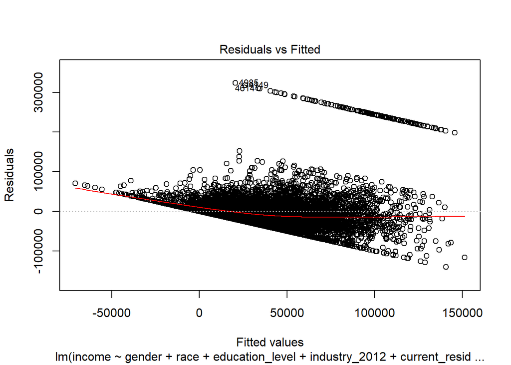

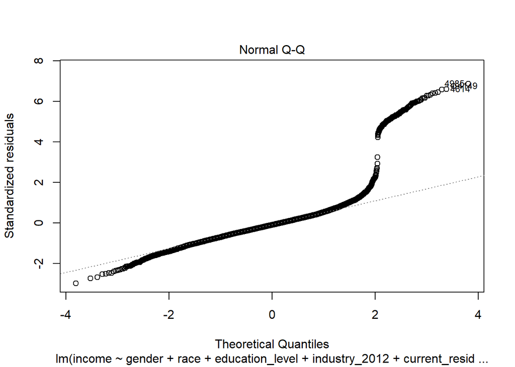

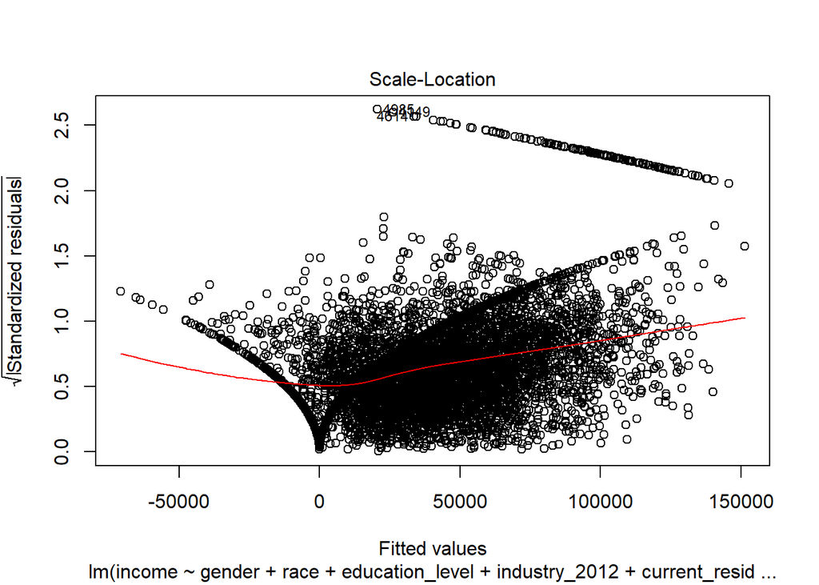

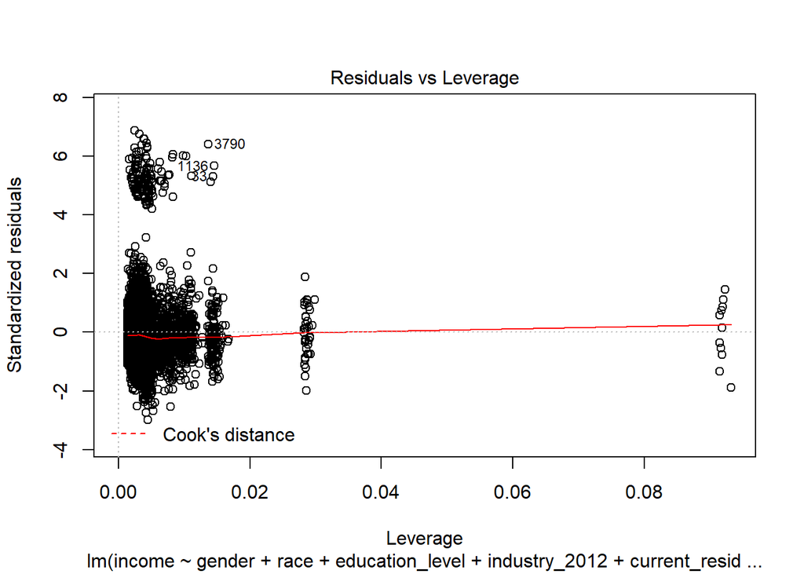

Omit zeros and topcoded values from income(dependent variable). So that we can appy log on income to make it look like normally distributed data

```
##
## Call:
## lm(formula = log(income) ~ gender + race + education_level +
##     industry_2012 + current_residence + FAMSIZE_2012 + Jobsnum_2012,
##     data = nlsy)
##
## Residuals:
##     Min      1Q  Median      3Q     Max
## -6.8392 -0.2820  0.1469  0.5009  2.0705
##
## Coefficients:
##                                     Estimate Std. Error t value Pr(>|t|)
## (Intercept)                         8.021074   0.141211  56.802  < 2e-16
## genderMale                          0.399670   0.027381  14.597  < 2e-16
## raceHispanic                        0.247205   0.037091   6.665 2.93e-11
## raceOther                           0.265361   0.029667   8.945  < 2e-16
## education_level                     0.120586   0.005502  21.918  < 2e-16
## industry_2012Mining                 1.135444   0.193332   5.873 4.55e-09
## industry_2012Utilities              0.945807   0.161365   5.861 4.88e-09
## industry_2012Construction           0.509688   0.126812   4.019 5.92e-05
## industry_2012Manufacturing          0.677577   0.122976   5.510 3.77e-08
## industry_2012Wholesale Trade        0.691251   0.139870   4.942 7.98e-07
## industry_2012Retail Trade           0.244387   0.125569   1.946 0.051681
## industry_2012Transportation         0.781675   0.127833   6.115 1.04e-09
## industry_2012Information            0.682250   0.144647   4.717 2.46e-06
## industry_2012Finance & Insurance    0.844688   0.133137   6.344 2.42e-10
## industry_2012Real Estate            0.454838   0.151565   3.001 0.002704
## industry_2012Technical Services     0.659862   0.133403   4.946 7.80e-07
## industry_2012Management Services    0.117945   0.130468   0.904 0.366031
## industry_2012Educational Services   0.372972   0.125689   2.967 0.003017
## industry_2012Health Care            0.507469   0.123424   4.112 3.99e-05
## industry_2012Arts & Entertainment   0.343373   0.157679   2.178 0.029477
## industry_2012Accomodations & Food   0.137119   0.135066   1.015 0.310059
## industry_2012Other Services         0.176670   0.131151   1.347 0.178018
## industry_2012Public Administration  0.787075   0.127103   6.192 6.39e-10
## industry_2012Armed Forces           0.981545   0.354060   2.772 0.005587
## industry_2012Missing                0.517351   0.146176   3.539 0.000405
## current_residenceURBAN              0.086914   0.032089   2.709 0.006780
## FAMSIZE_2012                        0.019915   0.009153   2.176 0.029623
## Jobsnum_2012                       -0.020830   0.001827 -11.402  < 2e-16
```

[output cut: 20 more lines]

```
## industry_2012Arts & Entertainment  *
## industry_2012Accomodations & Food
## industry_2012Other Services
## industry_2012Public Administration ***
## industry_2012Armed Forces          **
## industry_2012Missing               ***
## current_residenceURBAN             **
## FAMSIZE_2012                       *
## Jobsnum_2012                       ***
## ---
## Signif. codes:  0 '***' 0.001 '**' 0.01 '*' 0.05 '.' 0.1 ' ' 1
##
## Residual standard error: 0.8829 on 5104 degrees of freedom
## Multiple R-squared:  0.226,  Adjusted R-squared:  0.2219
## F-statistic: 55.19 on 27 and 5104 DF,  p-value: < 2.2e-16
```

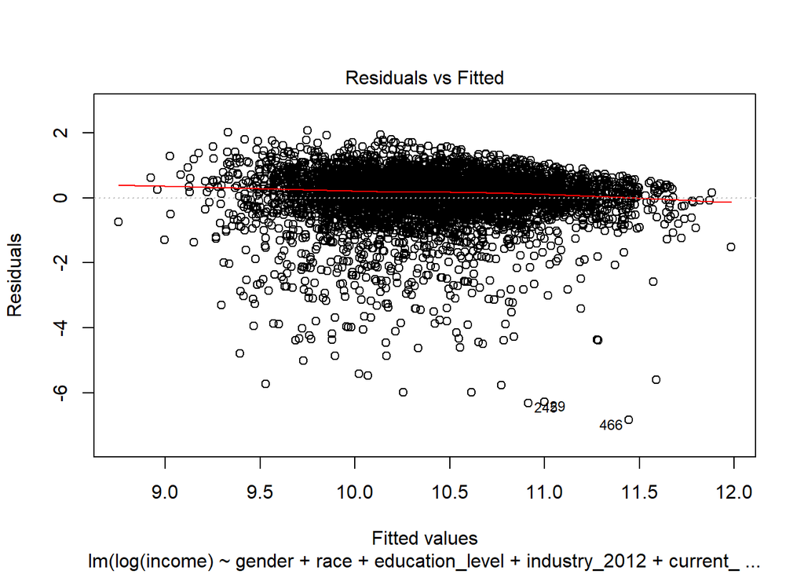

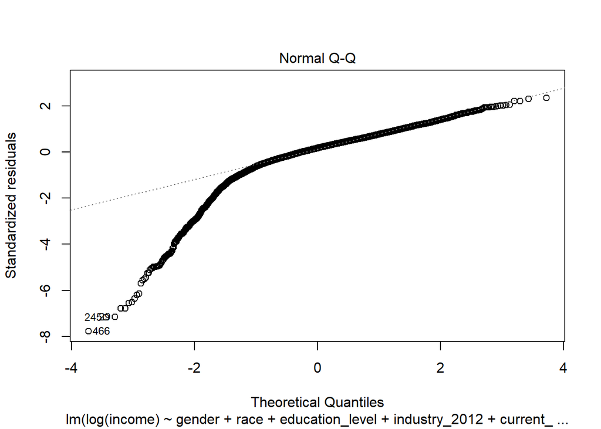

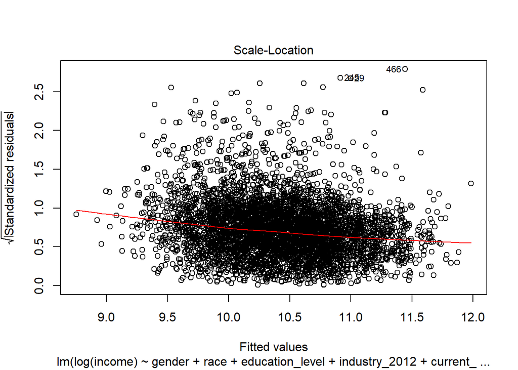

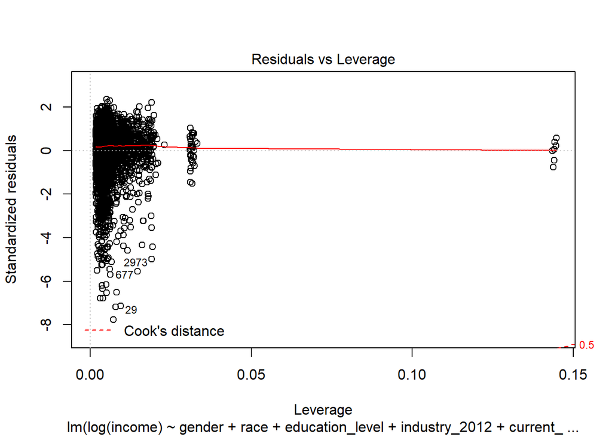

Residuals vs. Fitted: The residuals have near constant variance when plotted against fitted values Normal QQ plot: Better than before but the residuals from the regression do notlook approximately normally distributed. It looks skewed. Scale-location plot: There seems like a downward trend in this plot. Residuals vs Leverage: There seems to be outliers in the data.

Discussion

The main conclusion is that the difference in income is not only due gender but also other variables such as race, industry, level of education and number of jobs. The potential limitations of this analysis are the possibility of selection bias and omitted variable bias as there may be other factors that affect the income difference between male and women that I may not have accounted for. There are potential confounders that I did not account for, such as family income and marital status. The models in this analysis are somewhat believeable. However, I do not have much confidence in my analysis because of the possibility of omitted variable bais.Also becausem after including the interaction term, most of the coeffiencts are not significant.